# Understanding Domestic Violence: A Study on Abuse Among Jordanian Woman

RBB Final Project

Aya El Sammak

August 08, 2023

# 1 - Results of DHS Survey on Domestic Violence Against Women

## 1.1 Background

The purpose of this report is to present the outcomes of a DHS survey, with a specific focus on women who were selected and interviewed for the domestic violence module. Out of the total number of women surveyed (**14,689**), a subset of them (**6,852**) participated in the module

The findings indicate that a significant number of women (**1,542**) have experienced various forms of violence such as **physical, emotional**, and **sexual abuse**. This suggests that at least **22.5%** of women are victims of domestic violence.

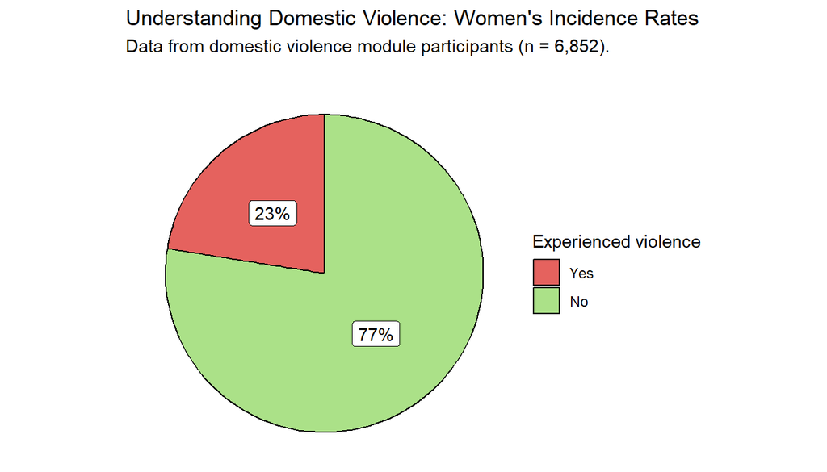

Figure 1a: Pie chart displaying the proportion of women that have experienced some form of domestic violence.

Among the women who experienced violence, a considerable portion (**273**) suffered injuries as a consequence of the abuse. The pie chart provides a visual representation of this finding, demonstrating that **18%** of women have endured injuries such as bruises, wounds, burns, or other similar harm.

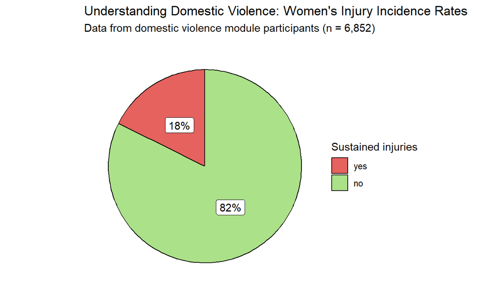

Figure 1b: Pie chart displaying the proportion of women that have been injured as a result of domestic violence.

### 1.1.1 Types of domestic violence among abused women

Emotional abuse is the most prevalent among the three types of abuse, with rates reaching as high as **80%**. This is followed by high rates of physical abuse (**66%**).

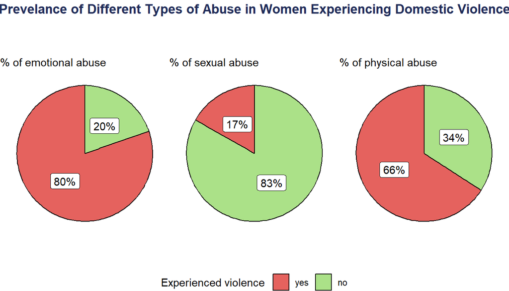

Figure 2: Proportions of types of abuse women have been subjected to.

## 1.2 Analysis

### 1.2.1 Domestic violence vs region

After looking at the data in more depth, it appears as though respondents residing in urban regions experience a higher likelihood of abuse compared to those living in rural areas.

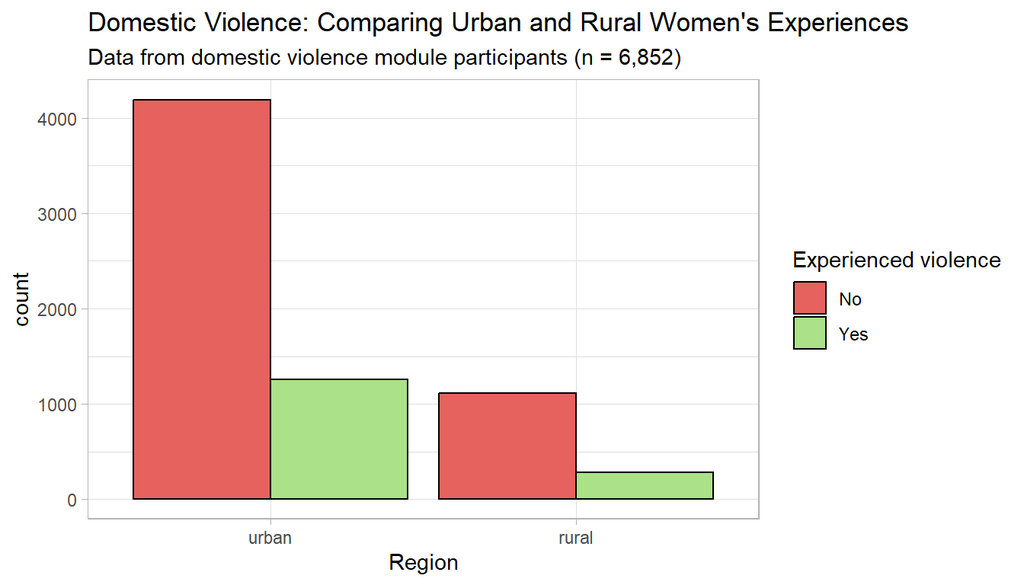

Figure 3: Prevalence of domestic violence according to the type of place of residence of the respondents.

The higher incidence of abuse in urban areas can be linked to the possibility that city environments may worsen existing tensions and create conditions that lead to more abuse, unlike the smaller and supportive communities commonly found in rural regions.

### 1.2.2 Domestic violence vs husbands’ educational levels

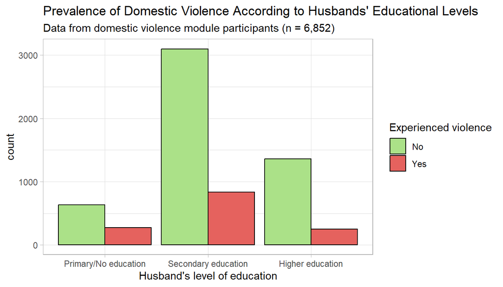

Figure 4: Prevalence of domestic violence across respondents’ husbands’ varying educational levels.

### 1.2.3 Domestic violence vs wealth index

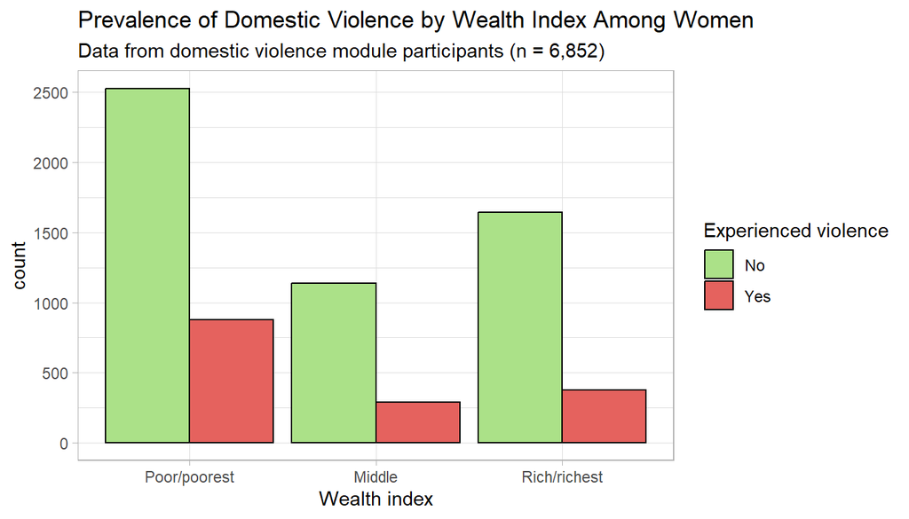

Figure 5: Prevalence of domestic violence by wealth index among women.

This could be due to the presence of higher levels of financial stress and economic hardships in poorer households.

### 1.2.4 Median age of abused women across different educational levels

The data suggests that abused women with higher education tend to be younger on average than those with lower or no education.

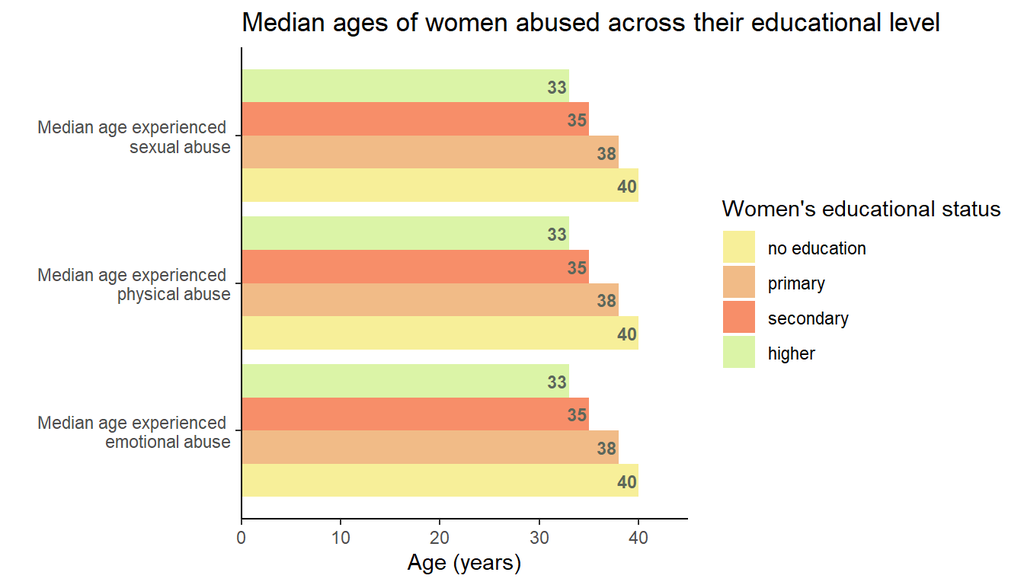

Figure 5: Median age of women by different types of abuse and grouped by their educational level.

Several reasons can explain this difference, including the fact that women that have had the luxury of education may be more capable of recognizing and addressing abuse. They are more likely to grasp the severity of their situation and report abuse to the appropriate authorities. On the other hand, the higher median age among women with lower education could be attributed to the years of enduring abuse, leading to a gradual accumulation of knowledge about identifying and dealing with abuse. Additionally, women with limited education may lack the resources or opportunities to speak up and seek help.

# 2 - Conclusion

This data highlights a disturbing reality where a significant number of women endure domestic violence in its various forms. It serves as a reminder of the ever-growing need to address and combat domestic violence and support victims in order to create a world where individuals, men or women, live free from fear and abuse.

# 3 - Additional: Exploring the Knowledge and Use of Contraceptive Methods among Women in the DHS Survey

## 3.1 Trends in contraceptive use across respondents’ age

Beyond the age of 30, there is a noticeable increase in the use of modern contraceptive methods, indicating a preference for avoiding pregnancy during this stage.

The usage of contraceptive methods then declines sharply after the onset of menopause, with no contraceptive use reaching its peak.

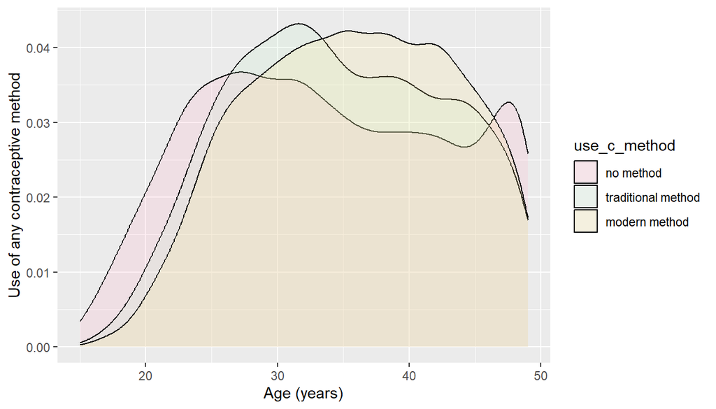

Figure 7: Change in use of contraceptive methods as women age.

## 3.2 Comparing median ages of women at first birth with varying contraceptive knowledge

The median age of women who are unaware of any contraceptive methods is lower compared to those who do know about contraception. However, there is no noticeable difference in median age between those who know about traditional methods and those who know about modern methods of contraception.

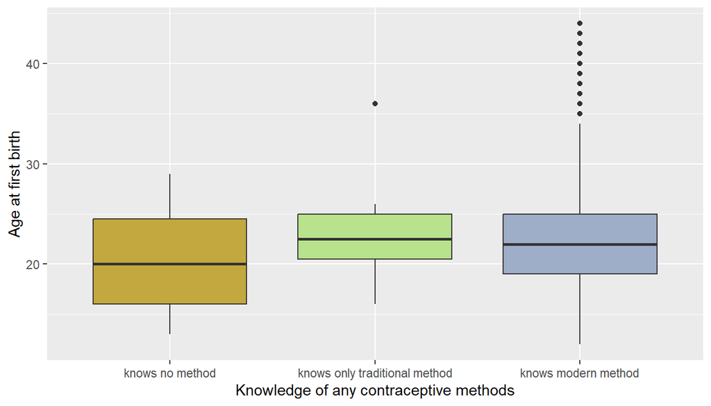

Figure 8: Median ages at first birth across different levels of contraceptive knowledge among women.

The findings suggest that lack of contraceptive knowledge may lead to earlier first births among women, while the specific type of contraceptive method used does not seem to have a notable effect on the timing of first births.